# Spatiotemporal Analysis of Reported Direct GHG Emissions from Large Direct-Emitting Facilities in North Carolina, 2019–2023

Erchi Luo and Haochuan Zhan

2026-04-24

# 1 Introduction

The EPA Greenhouse Gas Reporting Program requires large facilities above the reporting threshold to submit annual emissions data. This project examines reported direct greenhouse gas emissions from large direct-emitting facilities in North Carolina from 2019 to 2023. North Carolina provides a useful case because it contains multiple large facilities across different counties, which makes it possible to study both spatial concentration and short-term temporal change in reported emissions.

This project follows a reproducible R-based workflow that combines data cleaning, exploratory analysis, and introductory analytical methods. The central goal is to determine whether reported emissions were concentrated in a small number of counties and whether statewide reported emissions declined over the study period.

# 2 Research Questions

1. Are facility emissions concentrated in a small number of North Carolina counties?
2. Did statewide reported direct GHG emissions decline from 2019 to 2023?

# 3 Hypotheses

1. Reported direct GHG emissions are concentrated in a small number of North Carolina counties.
2. Statewide reported direct GHG emissions from North Carolina large direct-emitting facilities declined from 2019 to 2023.

# 4 Data Description

The project uses the EPA Greenhouse Gas Reporting Program downloadable workbook. For this analysis, the workbook was accessed as a manually downloaded Excel file and stored in the `data/raw/` folder of the project. Because the dataset is published by a United States federal agency, it is treated here as public-domain data for course-based analysis.

The report focuses on the `Direct Point Emitters` sheet and restricts the dataset to North Carolina facilities. This sheet was selected because it provides facility-level direct emissions records, which are appropriate for county-level aggregation and statewide trend summaries. The main variable of interest is total reported direct emissions in metric tons CO2e.

At this stage, the processed data include a cleaned wide-format facility dataset, a long-format facility-year dataset, a complete-reporting facility subset, and statewide annual totals for complete-reporting facilities. These files were produced from the raw workbook through scripted processing in R.

Initial summary of the North Carolina facility dataset.

| metric | value |
| --- | --- |
| NC facilities in initial subset | 161 |
| Rows with missing county | 2 |
| Rows with missing latitude | 0 |
| Rows with missing longitude | 0 |

Table 1 summarizes the size of the North Carolina subset and the main missing-data issues identified during the cleaning process.

# 5 Cleaning and Processing

The workflow begins with the GHGRP workbook stored in data/raw/. The Direct Point Emitters sheet is read into R, and the data are filtered to facilities located in North Carolina. Core facility fields and annual emissions columns for 2019 through 2023 are retained.

County names are then standardized into a consistent format, and a cleaned wide-format dataset is created. After that, the annual emissions columns are reshaped from wide format to long format so that each facility-year observation occupies one row. A complete-reporting subset is also created by retaining only facilities with non-missing emissions records in all five years from 2019 to 2023. Finally, annual statewide totals are calculated from the complete-reporting subset.

All cleaning and restructuring steps are completed in R, and no manual edits are made to the raw workbook outside the scripted workflow.

# 6 Preliminary Data Check

The cleaned long-format dataset allows the project to examine both the distribution of facility-year emissions and the concentration of emissions across counties. The complete-reporting subset is used to summarize statewide annual change from 2019 to 2023.

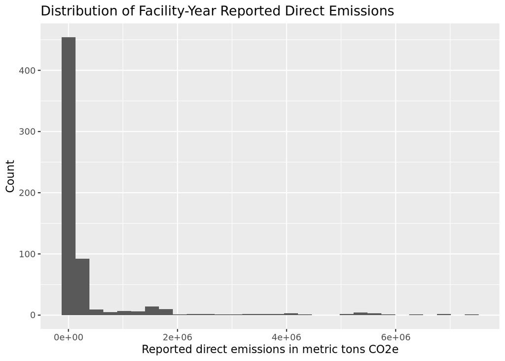

Figure 1 shows that the distribution of reported emissions is strongly right-skewed. Most facility-year observations are in the lower range, while a smaller number of facilities account for very large reported emissions.

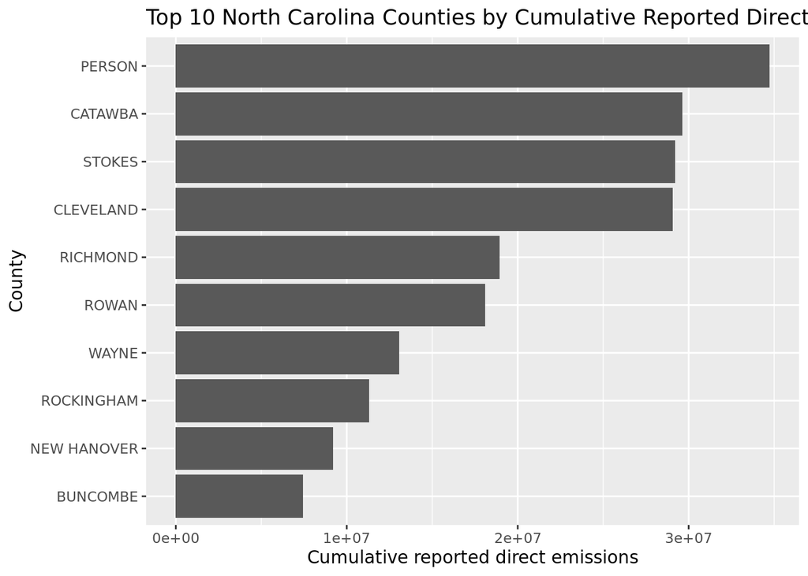

Figure 2 suggests that county-level reported emissions are highly uneven. A relatively small number of counties contribute a large share of cumulative emissions, which is consistent with the first research question.

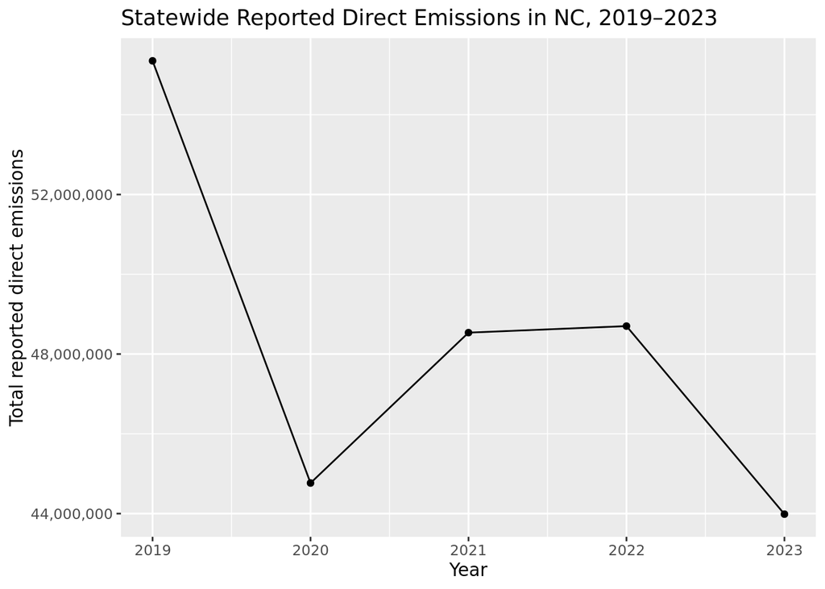

Figure 3 provides a first look at statewide change across the five-year period. The complete-reporting subset makes it possible to describe annual change while reducing distortions caused only by changes in reporting coverage.

# 7 Methods

To evaluate the first research question, cumulative reported direct emissions were summed across all available years for each county in the North Carolina facility dataset. County totals were then ranked from highest to lowest, and the shares represented by the top five and top ten counties were calculated. These measures provide a direct way to assess whether reported emissions were concentrated in a small number of counties.

To evaluate the second research question, statewide annual totals were calculated using only the complete-reporting facility subset. This subset includes facilities with non-missing emissions data in every year from 2019 through 2023. Using this balanced subset reduces the risk that apparent change is driven only by changes in reporting coverage rather than emissions levels.

# 8 Results

## 8.1 Research Question 1: County Concentration

Shares of cumulative statewide emissions represented by the top counties.

| metric | value |
| --- | --- |
| Top 5 counties share | 58.2% |
| Top 10 counties share | 82.5% |

The county concentration results support the first hypothesis. The top five counties accounted for 58.2% of cumulative reported direct emissions, while the top ten counties accounted for 82.5%. These values indicate that reported emissions were not evenly distributed across North Carolina counties. Instead, a relatively small number of counties contained a large share of cumulative reported emissions.

Top five North Carolina counties by cumulative reported direct emissions.

| county_clean | cumulative_emissions_mtco2e |
| --- | --- |
| PERSON | 34,730,455 |
| CATAWBA | 29,621,191 |
| STOKES | 29,209,747 |
| CLEVELAND | 29,081,607 |
| RICHMOND | 18,941,954 |

The highest-emitting counties were identified directly from the cumulative county totals. These counties dominated the statewide ranking and are consistent with the strong concentration pattern suggested by the bar chart.

## 8.2 Research Question 2: Statewide Change from 2019 to 2023

Statewide emissions change based on complete-reporting facilities.

| metric | value |
| --- | --- |
| 2019 total emissions | 55,351,069 |
| 2023 total emissions | 43,986,149 |
| Percent decline from 2019 to 2023 | 20.5% |

The statewide trend results support the second hypothesis. Reported direct emissions from complete-reporting facilities changed from 55,351,069 metric tons CO2e in 2019 to 43,986,149 metric tons CO2e in 2023. This represents a decline of 20.5%. Because the complete-reporting subset is used here, this result reflects the direction of change among consistently reporting facilities rather than changes caused only by entries appearing or disappearing across years.

# 9 Discussion

Two main findings emerge from this analysis. First, reported direct greenhouse gas emissions were strongly concentrated in a small number of North Carolina counties. The top five counties accounted for more than half of cumulative reported emissions, and the top ten counties accounted for more than four-fifths of the statewide total. This pattern is consistent with the idea that a relatively small number of counties contain the largest direct-emitting facilities rather than emissions being distributed evenly across the state.

Second, statewide reported direct emissions from complete-reporting facilities declined between 2019 and 2023. This result suggests that, among facilities with consistent reporting across all five years, the overall direction of change was downward. At the same time, the annual series should be interpreted cautiously because the study period is short and the analysis is descriptive rather than causal.

Taken together, these results show that the GHGRP facility dataset is sufficient to answer both research questions at an introductory analytical level. The county-level analysis identifies where reported emissions were concentrated, while the complete-reporting subset provides a clearer basis for describing recent statewide change.

# 10 Limitations

This analysis has several limitations. First, the GHGRP includes only facilities above the federal reporting threshold, so it does not represent all greenhouse gas sources in North Carolina. Second, the study focuses on reported direct facility emissions and therefore does not describe the full statewide greenhouse gas profile. Third, the five-year time window is relatively short, which limits how strongly the statewide trend can be interpreted. Fourth, the statewide trend analysis relies on the complete-reporting subset rather than the full facility pool, because reporting coverage changes across facilities over time. Finally, the analysis is descriptive and does not identify the operational, economic, or policy mechanisms that produced the observed patterns.

# 11 Conclusion

This project used EPA GHGRP facility data to examine reported direct greenhouse gas emissions from large direct-emitting facilities in North Carolina from 2019 to 2023. The results show that reported emissions were highly concentrated in a small number of counties, with the top five counties accounting for more than half of cumulative reported emissions and the top ten counties accounting for more than four-fifths of the statewide total. The results also show that statewide emissions from complete-reporting facilities declined from 2019 to 2023.

Overall, the project supports the conclusion that reported direct emissions from large North Carolina facilities were geographically concentrated and that the balanced subset of complete-reporting facilities showed a net decline over the study period. These conclusions are based on a reproducible R workflow, transparent data cleaning, descriptive visualization, and introductory analytical methods that match the scope of the course.

# 12 References

U.S. Environmental Protection Agency. Greenhouse Gas Reporting Program data. Accessed from the EPA GHGRP downloadable workbook used in this project.

Walker, K. County boundary data retrieved in R using the `tigris` package.

Wickham, H., François, R., Henry, L., Müller, K., and Vaughan, D. `dplyr`: A Grammar of Data Manipulation.

Wickham, H., Vaughan, D., and Girlich, M. `tidyr`: Tidy Messy Data.

Wickham, H. `ggplot2`: Create Elegant Data Visualisations Using the Grammar of Graphics.